# Risk Factor Analysis

## Outcome Variable

**Outcome Variable:** whz

## Predictor Variables

**Intervention Variable:** hfoodsec

**Adjustment Set:**

- arm
- sex
- W_mage
- meducyrs
- feducyrs
- hhwealth_quart
- vagbrth
- W_nrooms
- W_nchldlt5
- brthmon
- W_parity
- impfloor
- impsan
- safeh20
- delta_W_mage
- delta_meducyrs
- delta_feducyrs
- delta_hhwealth_quart
- delta_vagbrth
- delta_W_nrooms
- delta_W_nchldlt5
- delta_brthmon
- delta_W_parity
- delta_impfloor
- delta_impsan
- delta_safeh20

## Stratifying Variables

The analysis was stratified on these variable(s):

- agecat
- studyid
- country

## Data Summary

| agecat | studyid | country | hfoodsec | n_cell | n | outcome_variable |
| --- | --- | --- | --- | --- | --- | --- |
| Birth | GMS-Nepal | NEPAL | Food Secure | 442 | 620 | whz |
| Birth | GMS-Nepal | NEPAL | Mildly Food Insecure | 100 | 620 | whz |
| Birth | GMS-Nepal | NEPAL | Food Insecure | 78 | 620 | whz |
| Birth | JiVitA-3 | BANGLADESH | Food Secure | 5797 | 11763 | whz |
| Birth | JiVitA-3 | BANGLADESH | Mildly Food Insecure | 3947 | 11763 | whz |
| Birth | JiVitA-3 | BANGLADESH | Food Insecure | 2019 | 11763 | whz |
| Birth | JiVitA-4 | BANGLADESH | Food Secure | 1205 | 2383 | whz |
| Birth | JiVitA-4 | BANGLADESH | Mildly Food Insecure | 870 | 2383 | whz |
| Birth | JiVitA-4 | BANGLADESH | Food Insecure | 308 | 2383 | whz |
| Birth | MAL-ED | BANGLADESH | Food Secure | 138 | 162 | whz |
| Birth | MAL-ED | BANGLADESH | Mildly Food Insecure | 3 | 162 | whz |
| Birth | MAL-ED | BANGLADESH | Food Insecure | 21 | 162 | whz |
| Birth | MAL-ED | BRAZIL | Food Secure | 0 | 26 | whz |
| Birth | MAL-ED | BRAZIL | Mildly Food Insecure | 4 | 26 | whz |
| Birth | MAL-ED | BRAZIL | Food Insecure | 22 | 26 | whz |
| Birth | MAL-ED | INDIA | Food Secure | 32 | 35 | whz |
| Birth | MAL-ED | INDIA | Mildly Food Insecure | 1 | 35 | whz |
| Birth | MAL-ED | INDIA | Food Insecure | 2 | 35 | whz |
| Birth | MAL-ED | NEPAL | Food Secure | 10 | 14 | whz |
| Birth | MAL-ED | NEPAL | Mildly Food Insecure | 1 | 14 | whz |
| Birth | MAL-ED | NEPAL | Food Insecure | 3 | 14 | whz |
| Birth | MAL-ED | PERU | Food Secure | 23 | 89 | whz |
| Birth | MAL-ED | PERU | Mildly Food Insecure | 22 | 89 | whz |
| Birth | MAL-ED | PERU | Food Insecure | 44 | 89 | whz |
| Birth | MAL-ED | SOUTH AFRICA | Food Secure | 45 | 87 | whz |
| Birth | MAL-ED | SOUTH AFRICA | Mildly Food Insecure | 9 | 87 | whz |
| Birth | MAL-ED | SOUTH AFRICA | Food Insecure | 33 | 87 | whz |
| Birth | NIH-Birth | BANGLADESH | Food Secure | 86 | 575 | whz |
| Birth | NIH-Birth | BANGLADESH | Mildly Food Insecure | 453 | 575 | whz |
| Birth | NIH-Birth | BANGLADESH | Food Insecure | 36 | 575 | whz |

[output cut: 69 more lines]

The following strata were considered:

- agecat: 24 months, studyid: GMS-Nepal, country: NEPAL
- agecat: 24 months, studyid: JiVitA-3, country: BANGLADESH
- agecat: 24 months, studyid: JiVitA-4, country: BANGLADESH
- agecat: 24 months, studyid: MAL-ED, country: BANGLADESH
- agecat: 24 months, studyid: MAL-ED, country: BRAZIL
- agecat: 24 months, studyid: MAL-ED, country: INDIA
- agecat: 24 months, studyid: MAL-ED, country: NEPAL
- agecat: 24 months, studyid: MAL-ED, country: PERU
- agecat: 24 months, studyid: MAL-ED, country: SOUTH AFRICA
- agecat: 24 months, studyid: NIH-Birth, country: BANGLADESH
- agecat: 24 months, studyid: NIH-Crypto, country: BANGLADESH
- agecat: 6 months, studyid: GMS-Nepal, country: NEPAL
- agecat: 6 months, studyid: JiVitA-3, country: BANGLADESH
- agecat: 6 months, studyid: JiVitA-4, country: BANGLADESH
- agecat: 6 months, studyid: MAL-ED, country: BANGLADESH
- agecat: 6 months, studyid: MAL-ED, country: BRAZIL
- agecat: 6 months, studyid: MAL-ED, country: INDIA
- agecat: 6 months, studyid: MAL-ED, country: NEPAL
- agecat: 6 months, studyid: MAL-ED, country: PERU
- agecat: 6 months, studyid: MAL-ED, country: SOUTH AFRICA
- agecat: 6 months, studyid: NIH-Birth, country: BANGLADESH
- agecat: 6 months, studyid: NIH-Crypto, country: BANGLADESH
- agecat: Birth, studyid: GMS-Nepal, country: NEPAL
- agecat: Birth, studyid: JiVitA-3, country: BANGLADESH
- agecat: Birth, studyid: JiVitA-4, country: BANGLADESH
- agecat: Birth, studyid: MAL-ED, country: BANGLADESH
- agecat: Birth, studyid: MAL-ED, country: BRAZIL
- agecat: Birth, studyid: MAL-ED, country: INDIA
- agecat: Birth, studyid: MAL-ED, country: NEPAL
- agecat: Birth, studyid: MAL-ED, country: PERU
- agecat: Birth, studyid: MAL-ED, country: SOUTH AFRICA
- agecat: Birth, studyid: NIH-Birth, country: BANGLADESH
- agecat: Birth, studyid: NIH-Crypto, country: BANGLADESH

### Dropped Strata

Some strata were dropped due to rare outcomes:

- agecat: Birth, studyid: MAL-ED, country: BANGLADESH
- agecat: Birth, studyid: MAL-ED, country: BRAZIL
- agecat: Birth, studyid: MAL-ED, country: INDIA
- agecat: Birth, studyid: MAL-ED, country: NEPAL
- agecat: 6 months, studyid: MAL-ED, country: BANGLADESH
- agecat: 6 months, studyid: MAL-ED, country: BRAZIL
- agecat: 24 months, studyid: MAL-ED, country: BANGLADESH
- agecat: 24 months, studyid: MAL-ED, country: BRAZIL

## Methods Detail

We’re interested in the causal parameters $E[Y_a]$ for all values of $a \in \mathcal{A}$. These parameters represent the mean outcome if, possibly contrary to fact, we intervened to set all units to have $A=a$. Under the randomization and positivity assumptions, these are identified by the statistical parameters $\psi_a=E_W[E_{Y|A,W}(Y|A=a,W)]$. In addition, we’re interested in the mean of $Y$, $E[Y]$ under no intervention (the observed mean). We will estimate these parameters by using SuperLearner to fit the relevant likelihood factors – $E_{Y|A,W}(Y|A=a,W)$ and $p(A=a|W)$, and then updating our likelihood fit using a joint TMLE.

For unadjusted analyses ($W=\{\}$), initial likelihoods were estimated using Lrnr_glm to estimate the simple $E(Y|A)$ and Lrnr_mean to estimate $p(A)$. For adjusted analyses, a small library containing Lrnr_glmnet, Lrnr_xgboost, and Lrnr_mean was used.

Having estimated these parameters, we will then use the delta method to estimate relative risks and attributable risks relative to a prespecified baseline level of $A$.

# Results Detail

## Results Plots

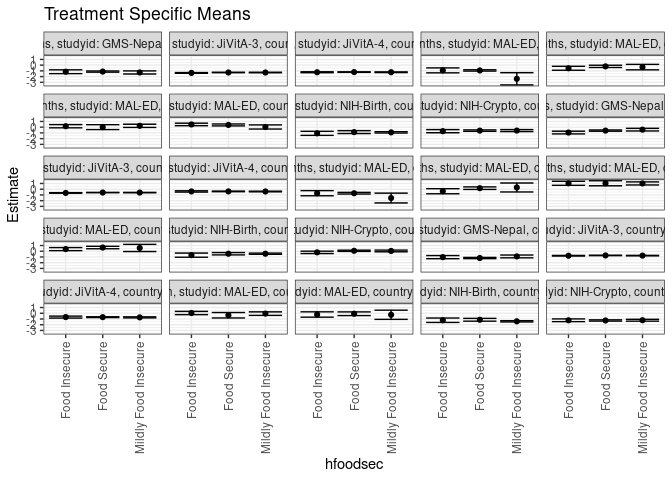

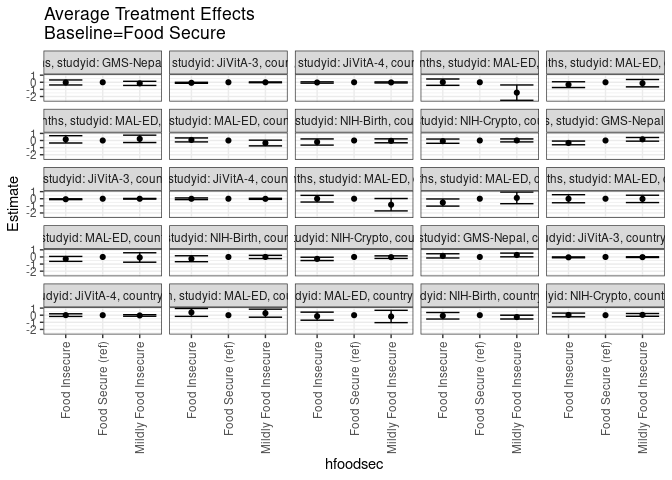

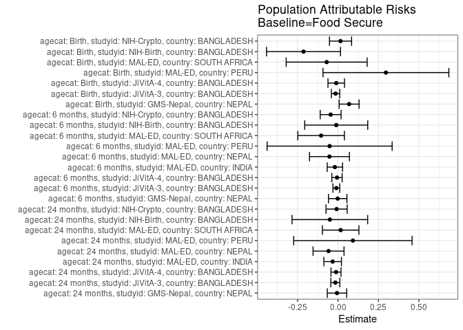

## Results Table

### Parameter: TSM

| agecat | studyid | country | intervention_level | baseline_level | estimate | ci_lower | ci_upper |
| --- | --- | --- | --- | --- | --- | --- | --- |
| Birth | GMS-Nepal | NEPAL | Food Secure | NA | -1.1852160 | -1.2896735 | -1.0807584 |
| Birth | GMS-Nepal | NEPAL | Mildly Food Insecure | NA | -0.9044332 | -1.1484229 | -0.6604436 |
| Birth | GMS-Nepal | NEPAL | Food Insecure | NA | -1.0304757 | -1.3045453 | -0.7564062 |
| Birth | JiVitA-3 | BANGLADESH | Food Secure | NA | -0.7354472 | -0.7702059 | -0.7006885 |
| Birth | JiVitA-3 | BANGLADESH | Mildly Food Insecure | NA | -0.7621701 | -0.8032399 | -0.7211002 |
| Birth | JiVitA-3 | BANGLADESH | Food Insecure | NA | -0.7860452 | -0.8385546 | -0.7335359 |
| Birth | JiVitA-4 | BANGLADESH | Food Secure | NA | -0.6786960 | -0.7458871 | -0.6115049 |
| Birth | JiVitA-4 | BANGLADESH | Mildly Food Insecure | NA | -0.7167405 | -0.8048466 | -0.6286344 |
| Birth | JiVitA-4 | BANGLADESH | Food Insecure | NA | -0.6662287 | -0.8379843 | -0.4944730 |
| Birth | MAL-ED | PERU | Food Secure | NA | -0.3445132 | -0.8209544 | 0.1319281 |
| Birth | MAL-ED | PERU | Mildly Food Insecure | NA | -0.0605893 | -0.3656944 | 0.2445158 |
| Birth | MAL-ED | PERU | Food Insecure | NA | 0.0456000 | -0.2370900 | 0.3282901 |
| Birth | MAL-ED | SOUTH AFRICA | Food Secure | NA | -0.0800000 | -0.4003913 | 0.2403913 |
| Birth | MAL-ED | SOUTH AFRICA | Mildly Food Insecure | NA | -0.2611111 | -1.0678216 | 0.5455994 |
| Birth | MAL-ED | SOUTH AFRICA | Food Insecure | NA | -0.2157576 | -0.6840291 | 0.2525139 |
| Birth | NIH-Birth | BANGLADESH | Food Secure | NA | -1.1364598 | -1.3814858 | -0.8914338 |
| Birth | NIH-Birth | BANGLADESH | Mildly Food Insecure | NA | -1.4044781 | -1.5125291 | -1.2964272 |
| Birth | NIH-Birth | BANGLADESH | Food Insecure | NA | -1.2163293 | -1.6040322 | -0.8286264 |
| Birth | NIH-Crypto | BANGLADESH | Food Secure | NA | -1.2596573 | -1.3698623 | -1.1494523 |
| Birth | NIH-Crypto | BANGLADESH | Mildly Food Insecure | NA | -1.2145001 | -1.3752352 | -1.0537650 |
| Birth | NIH-Crypto | BANGLADESH | Food Insecure | NA | -1.2243429 | -1.4620725 | -0.9866133 |
| 6 months | GMS-Nepal | NEPAL | Food Secure | NA | -0.5999126 | -0.7070094 | -0.4928158 |
| 6 months | GMS-Nepal | NEPAL | Mildly Food Insecure | NA | -0.4350548 | -0.6658350 | -0.2042746 |
| 6 months | GMS-Nepal | NEPAL | Food Insecure | NA | -0.9411299 | -1.1785412 | -0.7037186 |
| 6 months | JiVitA-3 | BANGLADESH | Food Secure | NA | -0.5828308 | -0.6117429 | -0.5539187 |
| 6 months | JiVitA-3 | BANGLADESH | Mildly Food Insecure | NA | -0.5895227 | -0.6242757 | -0.5547698 |
| 6 months | JiVitA-3 | BANGLADESH | Food Insecure | NA | -0.6525960 | -0.7067216 | -0.5984704 |
| 6 months | JiVitA-4 | BANGLADESH | Food Secure | NA | -0.3832060 | -0.4315207 | -0.3348912 |
| 6 months | JiVitA-4 | BANGLADESH | Mildly Food Insecure | NA | -0.3974915 | -0.4554019 | -0.3395811 |
| 6 months | JiVitA-4 | BANGLADESH | Food Insecure | NA | -0.3891244 | -0.5002362 | -0.2780127 |
| 6 months | MAL-ED | INDIA | Food Secure | NA | -0.7025789 | -0.8453715 | -0.5597864 |
| 6 months | MAL-ED | INDIA | Mildly Food Insecure | NA | -1.5420000 | -2.3989104 | -0.6850896 |
| 6 months | MAL-ED | INDIA | Food Insecure | NA | -0.6978922 | -1.1435259 | -0.2522584 |
| 6 months | MAL-ED | NEPAL | Food Secure | NA | 0.1806544 | -0.0414061 | 0.4027150 |
| 6 months | MAL-ED | NEPAL | Mildly Food Insecure | NA | 0.2991350 | -0.4861842 | 1.0844542 |
| 6 months | MAL-ED | NEPAL | Food Insecure | NA | -0.3537679 | -0.7983281 | 0.0907923 |
| 6 months | MAL-ED | PERU | Food Secure | NA | 1.0338618 | 0.5957818 | 1.4719418 |
| 6 months | MAL-ED | PERU | Mildly Food Insecure | NA | 1.0083331 | 0.7393211 | 1.2773452 |
| 6 months | MAL-ED | PERU | Food Insecure | NA | 1.0321012 | 0.6794541 | 1.3847483 |
| 6 months | MAL-ED | SOUTH AFRICA | Food Secure | NA | 0.6476229 | 0.4303859 | 0.8648599 |
| 6 months | MAL-ED | SOUTH AFRICA | Mildly Food Insecure | NA | 0.5749817 | -0.0521490 | 1.2021123 |
| 6 months | MAL-ED | SOUTH AFRICA | Food Insecure | NA | 0.3741839 | 0.1052406 | 0.6431271 |
| 6 months | NIH-Birth | BANGLADESH | Food Secure | NA | -0.4363714 | -0.6385486 | -0.2341943 |
| 6 months | NIH-Birth | BANGLADESH | Mildly Food Insecure | NA | -0.4336478 | -0.5379883 | -0.3293074 |
| 6 months | NIH-Birth | BANGLADESH | Food Insecure | NA | -0.6857454 | -1.0506344 | -0.3208563 |
| 6 months | NIH-Crypto | BANGLADESH | Food Secure | NA | 0.0753719 | -0.0290210 | 0.1797648 |
| 6 months | NIH-Crypto | BANGLADESH | Mildly Food Insecure | NA | 0.0486034 | -0.0998705 | 0.1970774 |
| 6 months | NIH-Crypto | BANGLADESH | Food Insecure | NA | -0.1938020 | -0.4012606 | 0.0136566 |
| 24 months | GMS-Nepal | NEPAL | Food Secure | NA | -1.1240780 | -1.2270102 | -1.0211457 |
| 24 months | GMS-Nepal | NEPAL | Mildly Food Insecure | NA | -1.2766860 | -1.5487141 | -1.0046579 |
| 24 months | GMS-Nepal | NEPAL | Food Insecure | NA | -1.1525830 | -1.4864372 | -0.8187289 |
| 24 months | JiVitA-3 | BANGLADESH | Food Secure | NA | -1.2821687 | -1.3184888 | -1.2458487 |
| 24 months | JiVitA-3 | BANGLADESH | Mildly Food Insecure | NA | -1.2861361 | -1.3314436 | -1.2408287 |
| 24 months | JiVitA-3 | BANGLADESH | Food Insecure | NA | -1.3601867 | -1.4206842 | -1.2996892 |
| 24 months | JiVitA-4 | BANGLADESH | Food Secure | NA | -1.2119285 | -1.2563683 | -1.1674887 |
| 24 months | JiVitA-4 | BANGLADESH | Mildly Food Insecure | NA | -1.2343201 | -1.2894668 | -1.1791735 |
| 24 months | JiVitA-4 | BANGLADESH | Food Insecure | NA | -1.2431823 | -1.3231679 | -1.1631967 |
| 24 months | MAL-ED | INDIA | Food Secure | NA | -0.9256316 | -1.0440690 | -0.8071941 |
| 24 months | MAL-ED | INDIA | Mildly Food Insecure | NA | -2.3840000 | -3.4554070 | -1.3125930 |
| 24 months | MAL-ED | INDIA | Food Insecure | NA | -0.9111765 | -1.3418053 | -0.4805476 |
| 24 months | MAL-ED | NEPAL | Food Secure | NA | -0.2144751 | -0.4122145 | -0.0167357 |
| 24 months | MAL-ED | NEPAL | Mildly Food Insecure | NA | -0.3433831 | -0.8181203 | 0.1313541 |
| 24 months | MAL-ED | NEPAL | Food Insecure | NA | -0.5479632 | -0.8932140 | -0.2027124 |
| 24 months | MAL-ED | PERU | Food Secure | NA | 0.0061417 | -0.4205954 | 0.4328787 |
| 24 months | MAL-ED | PERU | Mildly Food Insecure | NA | 0.2381107 | -0.0431004 | 0.5193219 |
| 24 months | MAL-ED | PERU | Food Insecure | NA | 0.1686999 | -0.1114239 | 0.4488236 |
| 24 months | MAL-ED | SOUTH AFRICA | Food Secure | NA | 0.3916086 | 0.2232232 | 0.5599940 |
| 24 months | MAL-ED | SOUTH AFRICA | Mildly Food Insecure | NA | 0.0385444 | -0.3225547 | 0.3996435 |
| 24 months | MAL-ED | SOUTH AFRICA | Food Insecure | NA | 0.4743981 | 0.2538278 | 0.6949684 |
| 24 months | NIH-Birth | BANGLADESH | Food Secure | NA | -0.8610950 | -1.1118386 | -0.6103514 |
| 24 months | NIH-Birth | BANGLADESH | Mildly Food Insecure | NA | -0.9085448 | -1.0250640 | -0.7920256 |
| 24 months | NIH-Birth | BANGLADESH | Food Insecure | NA | -1.0742366 | -1.4289819 | -0.7194912 |
| 24 months | NIH-Crypto | BANGLADESH | Food Secure | NA | -0.6014475 | -0.7242301 | -0.4786649 |
| 24 months | NIH-Crypto | BANGLADESH | Mildly Food Insecure | NA | -0.5909647 | -0.7620669 | -0.4198625 |
| 24 months | NIH-Crypto | BANGLADESH | Food Insecure | NA | -0.6971775 | -0.9721144 | -0.4222405 |

### Parameter: E(Y)

| agecat | studyid | country | intervention_level | baseline_level | estimate | ci_lower | ci_upper |
| --- | --- | --- | --- | --- | --- | --- | --- |
| Birth | GMS-Nepal | NEPAL | NA | NA | -1.1165161 | -1.2055683 | -1.0274639 |
| Birth | JiVitA-3 | BANGLADESH | NA | NA | -0.7508875 | -0.7730765 | -0.7286985 |
| Birth | JiVitA-4 | BANGLADESH | NA | NA | -0.6898154 | -0.7422632 | -0.6373675 |
| Birth | MAL-ED | PERU | NA | NA | -0.0483146 | -0.2475806 | 0.1509514 |
| Birth | MAL-ED | SOUTH AFRICA | NA | NA | -0.1502299 | -0.4075620 | 0.1071022 |
| Birth | NIH-Birth | BANGLADESH | NA | NA | -1.3499217 | -1.4444634 | -1.2553801 |
| Birth | NIH-Crypto | BANGLADESH | NA | NA | -1.2441513 | -1.3281130 | -1.1601897 |
| 6 months | GMS-Nepal | NEPAL | NA | NA | -0.6018803 | -0.6892284 | -0.5145323 |
| 6 months | JiVitA-3 | BANGLADESH | NA | NA | -0.5932301 | -0.6127836 | -0.5736767 |
| 6 months | JiVitA-4 | BANGLADESH | NA | NA | -0.3895527 | -0.4270314 | -0.3520739 |
| 6 months | MAL-ED | INDIA | NA | NA | -0.7220008 | -0.8576809 | -0.5863207 |
| 6 months | MAL-ED | NEPAL | NA | NA | 0.1277734 | -0.0649431 | 0.3204900 |
| 6 months | MAL-ED | PERU | NA | NA | 0.9819369 | 0.7674415 | 1.1964324 |
| 6 months | MAL-ED | SOUTH AFRICA | NA | NA | 0.5429020 | 0.3813518 | 0.7044523 |
| 6 months | NIH-Birth | BANGLADESH | NA | NA | -0.4474038 | -0.5378167 | -0.3569909 |
| 6 months | NIH-Crypto | BANGLADESH | NA | NA | 0.0297622 | -0.0491685 | 0.1086930 |
| 24 months | GMS-Nepal | NEPAL | NA | NA | -1.1304997 | -1.2205265 | -1.0404728 |
| 24 months | JiVitA-3 | BANGLADESH | NA | NA | -1.2988352 | -1.3224626 | -1.2752078 |
| 24 months | JiVitA-4 | BANGLADESH | NA | NA | -1.2243590 | -1.2566569 | -1.1920612 |
| 24 months | MAL-ED | INDIA | NA | NA | -0.9588679 | -1.0774868 | -0.8402491 |
| 24 months | MAL-ED | NEPAL | NA | NA | -0.2730469 | -0.4358169 | -0.1102769 |
| 24 months | MAL-ED | PERU | NA | NA | 0.0982009 | -0.0794754 | 0.2758773 |
| 24 months | MAL-ED | SOUTH AFRICA | NA | NA | 0.4080227 | 0.2828348 | 0.5332106 |
| 24 months | NIH-Birth | BANGLADESH | NA | NA | -0.9115790 | -1.0095022 | -0.8136559 |
| 24 months | NIH-Crypto | BANGLADESH | NA | NA | -0.6103502 | -0.7050157 | -0.5156847 |

### Parameter: ATE

| agecat | studyid | country | intervention_level | baseline_level | estimate | ci_lower | ci_upper |
| --- | --- | --- | --- | --- | --- | --- | --- |
| Birth | GMS-Nepal | NEPAL | Food Secure | Food Secure | 0.0000000 | 0.0000000 | 0.0000000 |
| Birth | GMS-Nepal | NEPAL | Mildly Food Insecure | Food Secure | 0.2807828 | 0.0153233 | 0.5462422 |
| Birth | GMS-Nepal | NEPAL | Food Insecure | Food Secure | 0.1547402 | -0.1381095 | 0.4475900 |
| Birth | JiVitA-3 | BANGLADESH | Food Secure | Food Secure | 0.0000000 | 0.0000000 | 0.0000000 |
| Birth | JiVitA-3 | BANGLADESH | Mildly Food Insecure | Food Secure | -0.0267228 | -0.0782976 | 0.0248519 |
| Birth | JiVitA-3 | BANGLADESH | Food Insecure | Food Secure | -0.0505980 | -0.1119935 | 0.0107974 |
| Birth | JiVitA-4 | BANGLADESH | Food Secure | Food Secure | 0.0000000 | 0.0000000 | 0.0000000 |
| Birth | JiVitA-4 | BANGLADESH | Mildly Food Insecure | Food Secure | -0.0380445 | -0.1477830 | 0.0716939 |
| Birth | JiVitA-4 | BANGLADESH | Food Insecure | Food Secure | 0.0124673 | -0.1717668 | 0.1967014 |
| Birth | MAL-ED | PERU | Food Secure | Food Secure | 0.0000000 | 0.0000000 | 0.0000000 |
| Birth | MAL-ED | PERU | Mildly Food Insecure | Food Secure | 0.2839239 | -0.2815082 | 0.8493559 |
| Birth | MAL-ED | PERU | Food Insecure | Food Secure | 0.3901132 | -0.1654808 | 0.9457072 |
| Birth | MAL-ED | SOUTH AFRICA | Food Secure | Food Secure | 0.0000000 | 0.0000000 | 0.0000000 |
| Birth | MAL-ED | SOUTH AFRICA | Mildly Food Insecure | Food Secure | -0.1811111 | -1.0491159 | 0.6868937 |
| Birth | MAL-ED | SOUTH AFRICA | Food Insecure | Food Secure | -0.1357576 | -0.7031452 | 0.4316301 |
| Birth | NIH-Birth | BANGLADESH | Food Secure | Food Secure | 0.0000000 | 0.0000000 | 0.0000000 |
| Birth | NIH-Birth | BANGLADESH | Mildly Food Insecure | Food Secure | -0.2680183 | -0.5358562 | -0.0001804 |
| Birth | NIH-Birth | BANGLADESH | Food Insecure | Food Secure | -0.0798695 | -0.5386615 | 0.3789225 |
| Birth | NIH-Crypto | BANGLADESH | Food Secure | Food Secure | 0.0000000 | 0.0000000 | 0.0000000 |
| Birth | NIH-Crypto | BANGLADESH | Mildly Food Insecure | Food Secure | 0.0451572 | -0.1496301 | 0.2399445 |
| Birth | NIH-Crypto | BANGLADESH | Food Insecure | Food Secure | 0.0353144 | -0.2267804 | 0.2974093 |
| 6 months | GMS-Nepal | NEPAL | Food Secure | Food Secure | 0.0000000 | 0.0000000 | 0.0000000 |
| 6 months | GMS-Nepal | NEPAL | Mildly Food Insecure | Food Secure | 0.1648578 | -0.0911213 | 0.4208369 |
| 6 months | GMS-Nepal | NEPAL | Food Insecure | Food Secure | -0.3412173 | -0.6019636 | -0.0804711 |
| 6 months | JiVitA-3 | BANGLADESH | Food Secure | Food Secure | 0.0000000 | 0.0000000 | 0.0000000 |
| 6 months | JiVitA-3 | BANGLADESH | Mildly Food Insecure | Food Secure | -0.0066919 | -0.0506359 | 0.0372520 |
| 6 months | JiVitA-3 | BANGLADESH | Food Insecure | Food Secure | -0.0697651 | -0.1294214 | -0.0101089 |
| 6 months | JiVitA-4 | BANGLADESH | Food Secure | Food Secure | 0.0000000 | 0.0000000 | 0.0000000 |
| 6 months | JiVitA-4 | BANGLADESH | Mildly Food Insecure | Food Secure | -0.0142855 | -0.0851431 | 0.0565721 |
| 6 months | JiVitA-4 | BANGLADESH | Food Insecure | Food Secure | -0.0059185 | -0.1235023 | 0.1116654 |
| 6 months | MAL-ED | INDIA | Food Secure | Food Secure | 0.0000000 | 0.0000000 | 0.0000000 |
| 6 months | MAL-ED | INDIA | Mildly Food Insecure | Food Secure | -0.8394211 | -1.7081472 | 0.0293051 |
| 6 months | MAL-ED | INDIA | Food Insecure | Food Secure | 0.0046868 | -0.4632653 | 0.4726389 |
| 6 months | MAL-ED | NEPAL | Food Secure | Food Secure | 0.0000000 | 0.0000000 | 0.0000000 |
| 6 months | MAL-ED | NEPAL | Mildly Food Insecure | Food Secure | 0.1184805 | -0.6975024 | 0.9344635 |
| 6 months | MAL-ED | NEPAL | Food Insecure | Food Secure | -0.5344223 | -1.0359352 | -0.0329095 |
| 6 months | MAL-ED | PERU | Food Secure | Food Secure | 0.0000000 | 0.0000000 | 0.0000000 |
| 6 months | MAL-ED | PERU | Mildly Food Insecure | Food Secure | -0.0255287 | -0.5405792 | 0.4895219 |
| 6 months | MAL-ED | PERU | Food Insecure | Food Secure | -0.0017606 | -0.5686871 | 0.5651659 |
| 6 months | MAL-ED | SOUTH AFRICA | Food Secure | Food Secure | 0.0000000 | 0.0000000 | 0.0000000 |
| 6 months | MAL-ED | SOUTH AFRICA | Mildly Food Insecure | Food Secure | -0.0726412 | -0.7367418 | 0.5914593 |
| 6 months | MAL-ED | SOUTH AFRICA | Food Insecure | Food Secure | -0.2734390 | -0.6195270 | 0.0726489 |
| 6 months | NIH-Birth | BANGLADESH | Food Secure | Food Secure | 0.0000000 | 0.0000000 | 0.0000000 |
| 6 months | NIH-Birth | BANGLADESH | Mildly Food Insecure | Food Secure | 0.0027236 | -0.2246485 | 0.2300958 |
| 6 months | NIH-Birth | BANGLADESH | Food Insecure | Food Secure | -0.2493739 | -0.6676713 | 0.1689235 |
| 6 months | NIH-Crypto | BANGLADESH | Food Secure | Food Secure | 0.0000000 | 0.0000000 | 0.0000000 |
| 6 months | NIH-Crypto | BANGLADESH | Mildly Food Insecure | Food Secure | -0.0267685 | -0.2084007 | 0.1548637 |
| 6 months | NIH-Crypto | BANGLADESH | Food Insecure | Food Secure | -0.2691739 | -0.5016785 | -0.0366693 |
| 24 months | GMS-Nepal | NEPAL | Food Secure | Food Secure | 0.0000000 | 0.0000000 | 0.0000000 |
| 24 months | GMS-Nepal | NEPAL | Mildly Food Insecure | Food Secure | -0.1526080 | -0.4433682 | 0.1381522 |
| 24 months | GMS-Nepal | NEPAL | Food Insecure | Food Secure | -0.0285051 | -0.3779269 | 0.3209167 |
| 24 months | JiVitA-3 | BANGLADESH | Food Secure | Food Secure | 0.0000000 | 0.0000000 | 0.0000000 |
| 24 months | JiVitA-3 | BANGLADESH | Mildly Food Insecure | Food Secure | -0.0039674 | -0.0609404 | 0.0530056 |
| 24 months | JiVitA-3 | BANGLADESH | Food Insecure | Food Secure | -0.0780180 | -0.1461076 | -0.0099283 |
| 24 months | JiVitA-4 | BANGLADESH | Food Secure | Food Secure | 0.0000000 | 0.0000000 | 0.0000000 |
| 24 months | JiVitA-4 | BANGLADESH | Mildly Food Insecure | Food Secure | -0.0223917 | -0.0923622 | 0.0475788 |
| 24 months | JiVitA-4 | BANGLADESH | Food Insecure | Food Secure | -0.0312538 | -0.1226898 | 0.0601822 |
| 24 months | MAL-ED | INDIA | Food Secure | Food Secure | 0.0000000 | 0.0000000 | 0.0000000 |
| 24 months | MAL-ED | INDIA | Mildly Food Insecure | Food Secure | -1.4583684 | -2.5363018 | -0.3804350 |
| 24 months | MAL-ED | INDIA | Food Insecure | Food Secure | 0.0144551 | -0.4321640 | 0.4610742 |
| 24 months | MAL-ED | NEPAL | Food Secure | Food Secure | 0.0000000 | 0.0000000 | 0.0000000 |
| 24 months | MAL-ED | NEPAL | Mildly Food Insecure | Food Secure | -0.1289080 | -0.6468111 | 0.3889950 |
| 24 months | MAL-ED | NEPAL | Food Insecure | Food Secure | -0.3334881 | -0.7404433 | 0.0734670 |
| 24 months | MAL-ED | PERU | Food Secure | Food Secure | 0.0000000 | 0.0000000 | 0.0000000 |
| 24 months | MAL-ED | PERU | Mildly Food Insecure | Food Secure | 0.2319691 | -0.2851442 | 0.7490823 |
| 24 months | MAL-ED | PERU | Food Insecure | Food Secure | 0.1625582 | -0.3508582 | 0.6759747 |
| 24 months | MAL-ED | SOUTH AFRICA | Food Secure | Food Secure | 0.0000000 | 0.0000000 | 0.0000000 |
| 24 months | MAL-ED | SOUTH AFRICA | Mildly Food Insecure | Food Secure | -0.3530642 | -0.7540782 | 0.0479498 |
| 24 months | MAL-ED | SOUTH AFRICA | Food Insecure | Food Secure | 0.0827895 | -0.1964546 | 0.3620337 |
| 24 months | NIH-Birth | BANGLADESH | Food Secure | Food Secure | 0.0000000 | 0.0000000 | 0.0000000 |
| 24 months | NIH-Birth | BANGLADESH | Mildly Food Insecure | Food Secure | -0.0474498 | -0.3240189 | 0.2291193 |
| 24 months | NIH-Birth | BANGLADESH | Food Insecure | Food Secure | -0.2131416 | -0.6481355 | 0.2218524 |
| 24 months | NIH-Crypto | BANGLADESH | Food Secure | Food Secure | 0.0000000 | 0.0000000 | 0.0000000 |
| 24 months | NIH-Crypto | BANGLADESH | Mildly Food Insecure | Food Secure | 0.0104828 | -0.1986893 | 0.2196549 |
| 24 months | NIH-Crypto | BANGLADESH | Food Insecure | Food Secure | -0.0957300 | -0.3965222 | 0.2050623 |

### Parameter: PAR

| agecat | studyid | country | intervention_level | baseline_level | estimate | ci_lower | ci_upper |
| --- | --- | --- | --- | --- | --- | --- | --- |
| Birth | GMS-Nepal | NEPAL | Food Secure | NA | 0.0686998 | 0.0070846 | 0.1303150 |
| Birth | JiVitA-3 | BANGLADESH | Food Secure | NA | -0.0154403 | -0.0414367 | 0.0105560 |
| Birth | JiVitA-4 | BANGLADESH | Food Secure | NA | -0.0111194 | -0.0622115 | 0.0399727 |
| Birth | MAL-ED | PERU | Food Secure | NA | 0.2961986 | -0.0930022 | 0.6853993 |
| Birth | MAL-ED | SOUTH AFRICA | Food Secure | NA | -0.0702299 | -0.3205899 | 0.1801302 |
| Birth | NIH-Birth | BANGLADESH | Food Secure | NA | -0.2134619 | -0.4424159 | 0.0154921 |
| Birth | NIH-Crypto | BANGLADESH | Food Secure | NA | 0.0155060 | -0.0529631 | 0.0839751 |
| 6 months | GMS-Nepal | NEPAL | Food Secure | NA | -0.0019678 | -0.0589638 | 0.0550282 |
| 6 months | JiVitA-3 | BANGLADESH | Food Secure | NA | -0.0103993 | -0.0313144 | 0.0105158 |
| 6 months | JiVitA-4 | BANGLADESH | Food Secure | NA | -0.0063467 | -0.0382896 | 0.0255962 |
| 6 months | MAL-ED | INDIA | Food Secure | NA | -0.0194218 | -0.0668687 | 0.0280250 |
| 6 months | MAL-ED | NEPAL | Food Secure | NA | -0.0528810 | -0.1761385 | 0.0703765 |
| 6 months | MAL-ED | PERU | Food Secure | NA | -0.0519249 | -0.4385346 | 0.3346849 |
| 6 months | MAL-ED | SOUTH AFRICA | Food Secure | NA | -0.1047208 | -0.2488828 | 0.0394411 |
| 6 months | NIH-Birth | BANGLADESH | Food Secure | NA | -0.0110323 | -0.2058523 | 0.1837876 |
| 6 months | NIH-Crypto | BANGLADESH | Food Secure | NA | -0.0456097 | -0.1102917 | 0.0190724 |
| 24 months | GMS-Nepal | NEPAL | Food Secure | NA | -0.0064217 | -0.0664029 | 0.0535595 |
| 24 months | JiVitA-3 | BANGLADESH | Food Secure | NA | -0.0166664 | -0.0446452 | 0.0113123 |
| 24 months | JiVitA-4 | BANGLADESH | Food Secure | NA | -0.0124306 | -0.0435213 | 0.0186602 |
| 24 months | MAL-ED | INDIA | Food Secure | NA | -0.0332363 | -0.0875904 | 0.0211177 |
| 24 months | MAL-ED | NEPAL | Food Secure | NA | -0.0585718 | -0.1543649 | 0.0372214 |
| 24 months | MAL-ED | PERU | Food Secure | NA | 0.0920593 | -0.2739416 | 0.4580601 |
| 24 months | MAL-ED | SOUTH AFRICA | Food Secure | NA | 0.0164141 | -0.0964605 | 0.1292887 |
| 24 months | NIH-Birth | BANGLADESH | Food Secure | NA | -0.0504840 | -0.2843820 | 0.1834139 |
| 24 months | NIH-Crypto | BANGLADESH | Food Secure | NA | -0.0089027 | -0.0743220 | 0.0565166 |